# Reproducible Research: Peer Assessment 1

In this assignment we perform a brief review of a data set available by this link [Data-set: Activity monitoring data [52K]](https://d396qusza40orc.cloudfront.net/repdata%2Fdata%2Factivity.zip). The data consists of two months of data from an anonymous individual collected during the months of October and November, 2012 and include the number of steps taken in 5 minute intervals each day.

The variables included in this dataset are:

- steps: Number of steps taking in a 5-minute interval (missing values are coded as NA)
- date: The date on which the measurement was taken in YYYY-MM-DD format
- interval: Identifier for the 5-minute interval in which measurement was taken

The dataset is stored in a comma-separated-value (CSV) file and there are a total of 17,568 observations in this dataset.

## Loading and preprocessing the data

Let us first load the data and convert data variable to an appropriate format.

```r
if (! exists("DF")){
    download.file("https://d396qusza40orc.cloudfront.net/repdata%2Fdata%2Factivity.zip", "./activity.zip", method="wget")
    DF <- read.csv( unzip("./activity.zip") )
    }
DF <- transform(DF, date = as.Date(date))
```

We can check what is inside this dataset.

```r
head(DF)
```

```
##   steps       date interval
## 1    NA 2012-10-01        0
## 2    NA 2012-10-01        5
## 3    NA 2012-10-01       10
## 4    NA 2012-10-01       15
## 5    NA 2012-10-01       20
## 6    NA 2012-10-01       25
```

We see there are some missing values. We will deal with them in a while.

## What is mean total number of steps taken per day?

Now, let us consider how many steps were made in total on each day.

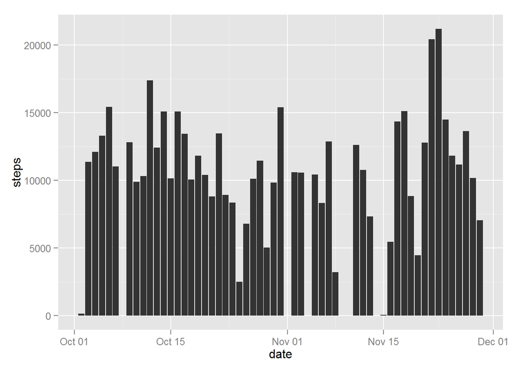

```r
library(ggplot2)
gSD <- ggplot(DF, aes(x = date, y = steps)) + stat_summary(fun.y="sum", geom="bar")
print(gSD)
```

And now let us take a look on the distribution - let us make a histogram

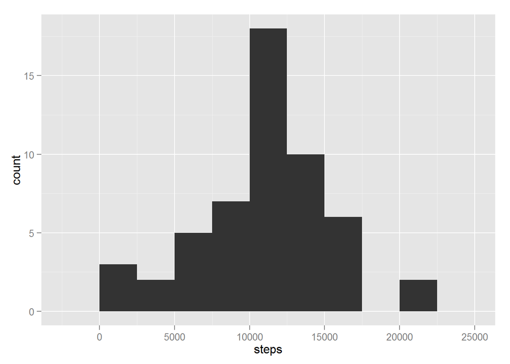

```r
forHist <- aggregate(steps ~ date, FUN=sum, data=DF)
gH <- ggplot(forHist, aes(x=steps)) + geom_histogram(binwidth=2500)
print(gH)
```

And here we calculate mean and median of total number of steps taken per day

```r
sBd <- aggregate(DF$steps, by=list(DF$date), FUN=sum)
MeanMedian <- c( mean(sBd$x, na.rm=TRUE), median(sBd$x, na.rm=TRUE) )
names(MeanMedian) <- c("mean", "median")
print(MeanMedian)
```

```
##   mean median
##  10766  10765
```